# Franco_Enrique_T3_p3

Enrique Franco García

22/3/2022

**Red de co-gustos**

Es necesario usar iGraph por lo cual hay que cargarla desde un principio

```r
library(igraph)
```

El primer paso a realizar es cargar nuestra red de co-gustos con ayuda de la función “read.csv”

```r
redcogustos <- read.csv("Red cogustos.csv")
row.names(redcogustos) <- redcogustos[,1]
redcogustos <- redcogustos[,-1]
red <- cor(t(redcogustos))
diag(red) <- 0
#Todas las funciones utilizadas posterior a cargar la red unicamente son para ordenar la red y que sea más fácil trabajar con ellas
```

Para la realizar la matriz de adyacencia se hace de la siguiente manera:

```r
adyacencia <- (1+red)/2 #La matriz de adyacencia es de utilidad ya que gracias a esta podemos ajustar de mejor manera los datoa
diag(adyacencia) <- 0
```

Por otro lado para realizar la matriz de adyacencia de la red dicótomica se hace de la siguiente manera:

```r
di_adyacencia <- ifelse(adyacencia > 0.5, 1, 0)
```

**Ejercicios:**

A partir de las dos versiones de la red de co-gustos: la dicotómica (D) y la pesada (P).:Elabora un programa en R que calcule

1. Dibuja la red con al menos tres layouts (D y P).

*A. Red dicótomica*

Para esto se crea la gráfica a partir de la matriz de adyacencia de la siguiente manera:

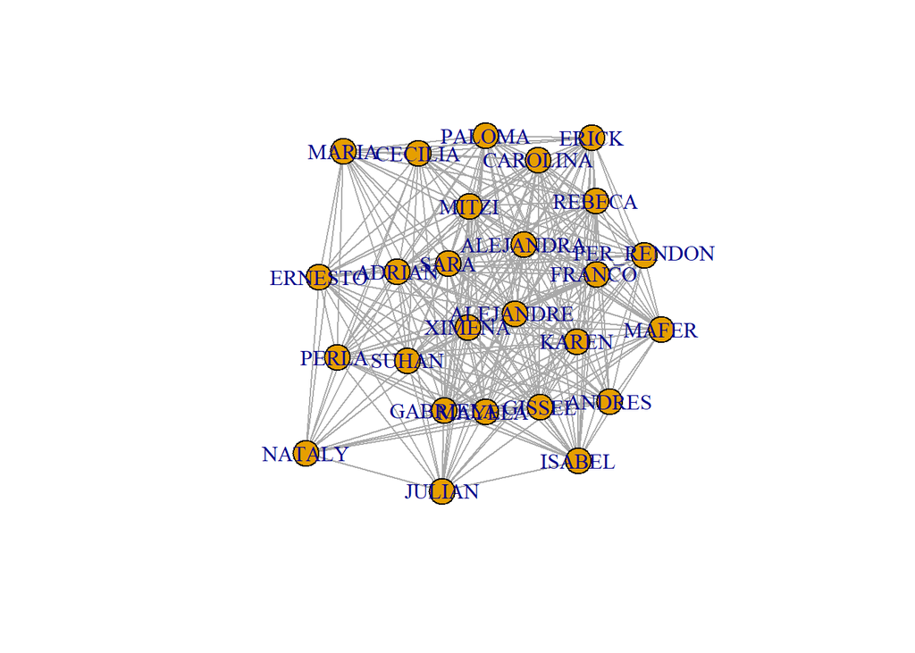

```r
g_dicotomica <- graph_from_adjacency_matrix(di_adyacencia, mode = "undirected")
plot(g_dicotomica)
```

Layouts con la red dicótomica

Para los layouts se hace de la siguiente manera:

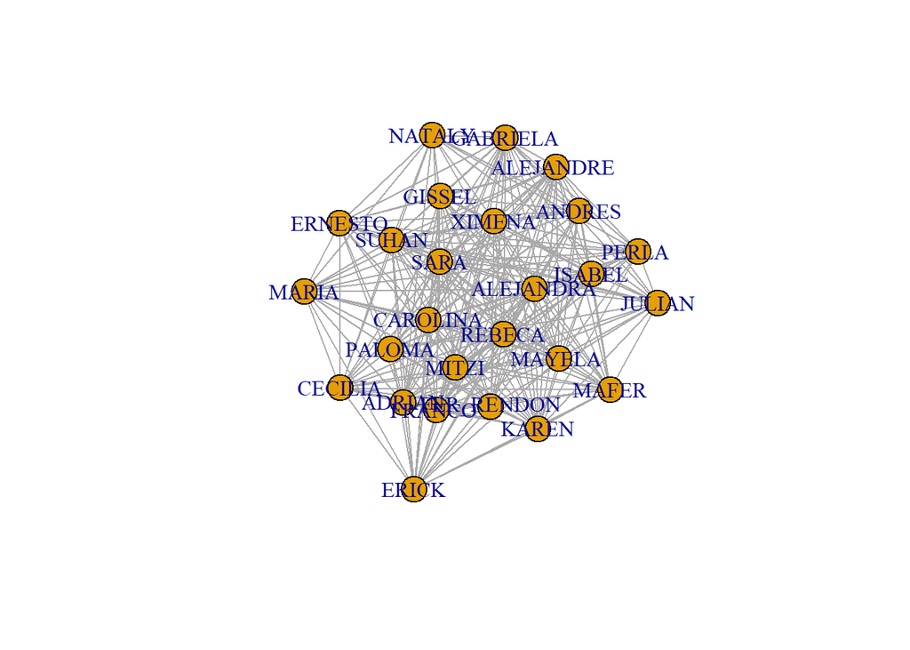

```r
#Primero
layout_dicotomica_1 <- layout.lgl(g_dicotomica)
LD_1 <- plot(g_dicotomica, layout = layout_dicotomica_1, edge.arrow.size = 0.5, vertex.sizes = 5)
```

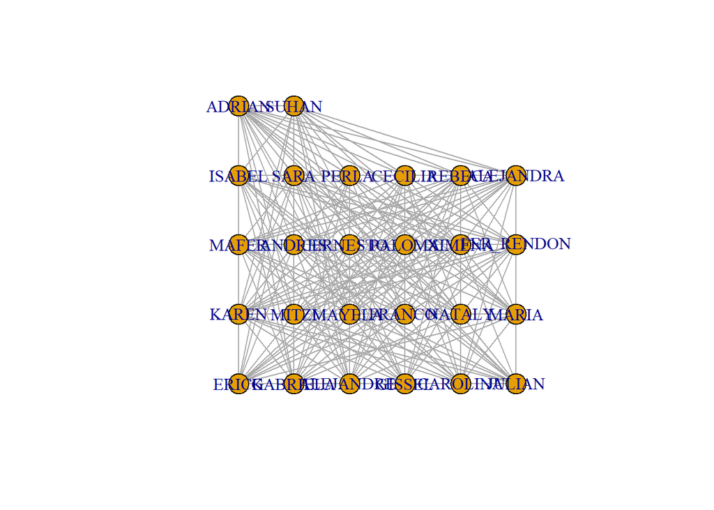

```r
#Segundo
layout_dicotomica_2 <- layout.grid(g_dicotomica)
LD_2 <- plot(g_dicotomica, layout = layout_dicotomica_2, edge.arrow.size = 0.5, vertex.sizes = 5)
```

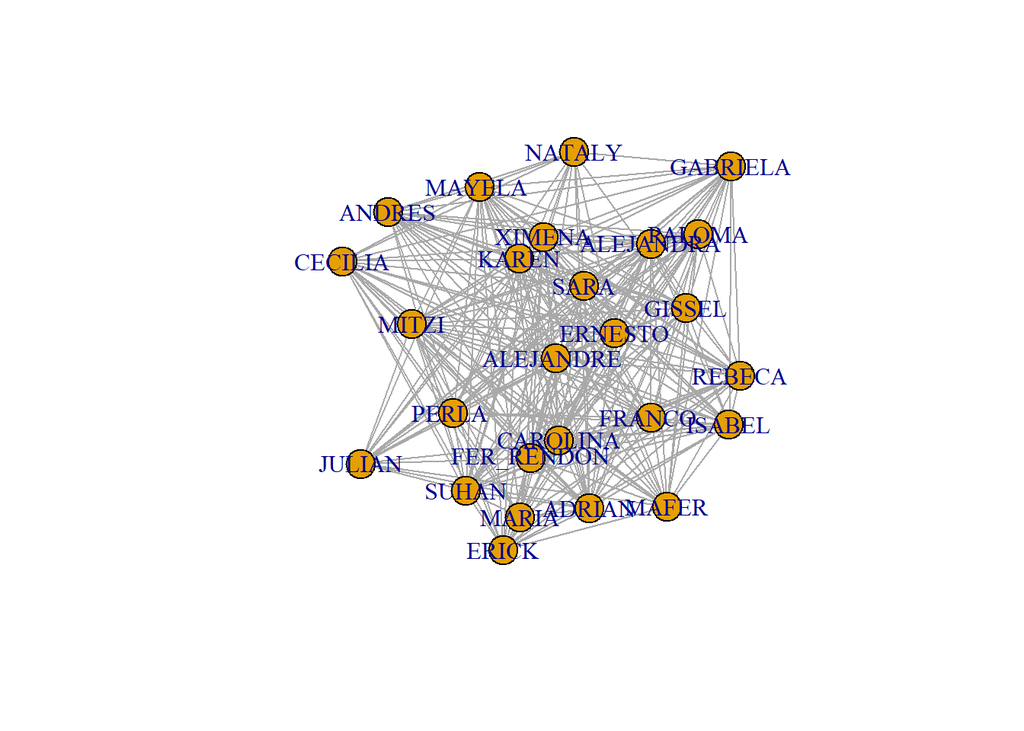

```r
#Tercero
layout_dicotomica_3 <- layout.drl(g_dicotomica)
LD_3 <- plot(g_dicotomica, layout = layout_dicotomica_3, edge.arrow.size = 0.5, vertex.sizes = 5)
```

*B. Red pesada*

Al igual que como lo hicimos con la red dicotómica aquí también vamos a generar la gráfica a partir de la matriz de adyacencia

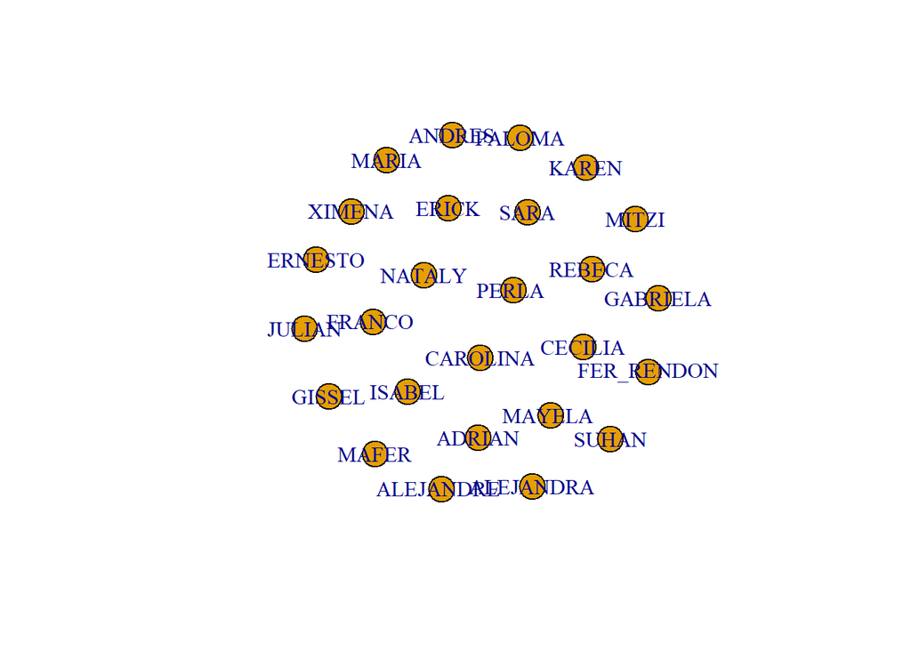

```r
g_pesada <- graph_from_adjacency_matrix(adyacencia, mode = "undirected")
plot(g_pesada)
```

Layouts con red pesada

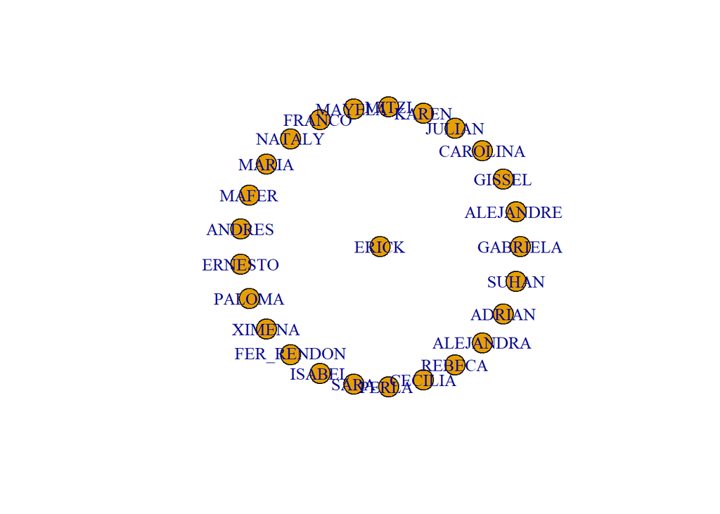

```r
layout_pesada_1 <- layout.star(g_pesada)
LP_1 <- plot(g_pesada, layout = layout_pesada_1, edge.arrow.size = 0.5, vertex.sizes = 5)
```

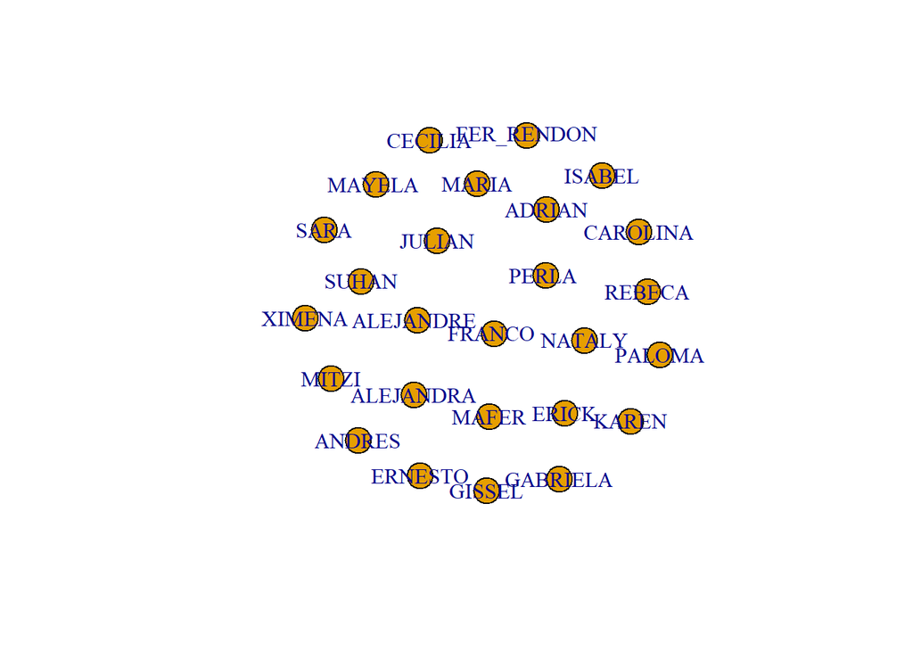

```r
layout_pesada_2 <- layout.auto(g_pesada)
LP_2 <- plot(g_pesada, layout = layout_pesada_2, edge.arrow.size = 0.5, vertex.sizes = 5)
```

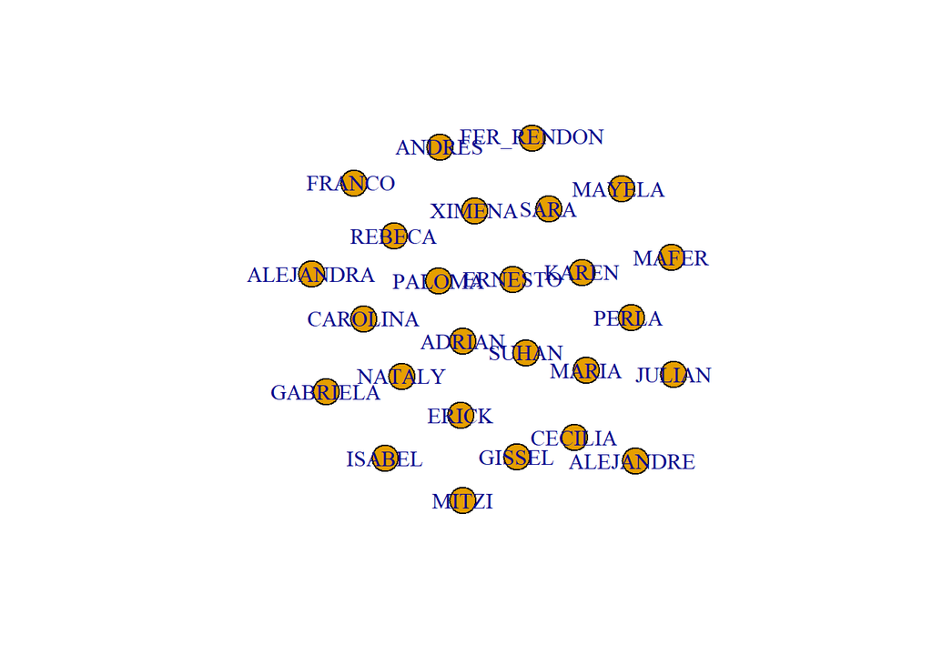

```r
layout_pesada_3 <- layout.graphopt(g_pesada)
LP_3 <- plot(g_pesada, layout = layout_pesada_3)
```

2. La distribución de conectividades (D).

```r
dc_dicotomica <- degree(g_dicotomica)
dc_dicotomica
```

```
##      ERICK   GABRIELA ALEJANDRE      GISSEL   CAROLINA     JULIAN      KAREN
##         20         22         24         21         21         17         22
##      MITZI    MAYELA     FRANCO      NATALY      MARIA      MAFER     ANDRES
##         23         23         21         13         16         19         19
##    ERNESTO     PALOMA     XIMENA FER_RENDON     ISABEL       SARA     PERLA
##         17         21         23         20         20         25         18
##    CECILIA     REBECA  ALEJANDRA     ADRIAN      SUHAN
##         19         21         22         23         22
```

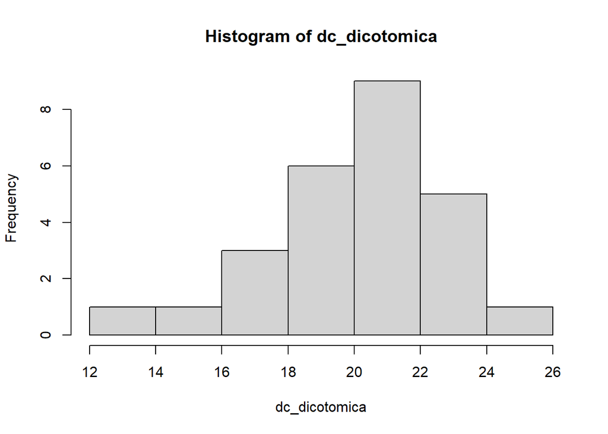

```r
hist(dc_dicotomica)
```

3. Los nodos más conectados (D)

```r
nodd <- degree(g_dicotomica, mode = "all")
sort(nodd, decreasing = TRUE)[1:13]
```

```
##       SARA ALEJANDRE       MITZI    MAYELA      XIMENA     ADRIAN   GABRIELA
##         25         24         23         23         23         23         22
##      KAREN  ALEJANDRA      SUHAN     GISSEL   CAROLINA    FRANCO
##         22         22         22         21         21         21
```

4. Los nodos más importantes con al menos tres medidas de centralidad (D)

```r
dcentralidad_1 <- centralization.betweenness(g_dicotomica)
dcentralidad_1
```

```
## $res
##  [1] 1.350671 3.064198 3.185622 2.360828 1.949695 1.658990 1.889539 2.776160
##  [9] 3.721304 1.397735 0.957572 1.338441 1.117638 2.110828 1.739329 2.636426
## [17] 3.401737 1.290204 1.353388 4.365828 1.818783 2.555471 1.527655 2.630674
## [25] 3.465821 3.335461
##
## $centralization
## [1] 0.007268205
##
## $theoretical_max
## [1] 7500
```

```r
dcentralidad_2 <- centralization.degree(g_dicotomica)
dcentralidad_2
```

```
## $res
##  [1] 20 22 24 21 21 17 22 23 23 21 13 16 19 19 17 21 23 20 20 25 18 19 21 22 23
## [26] 22
##
## $centralization
## [1] 0.1815385
##
## $theoretical_max
## [1] 650
```

```r
dcentralidad_3 <- centralization.closeness(g_dicotomica)
dcentralidad_3
```

```
## $res
##  [1] 0.8333333 0.8928571 0.9615385 0.8620690 0.8620690 0.7575758 0.8928571
##  [8] 0.9259259 0.9259259 0.8620690 0.6756757 0.7352941 0.8064516 0.8064516
## [15] 0.7575758 0.8620690 0.9259259 0.8333333 0.8333333 1.0000000 0.7812500
## [22] 0.8064516 0.8620690 0.8928571 0.9259259 0.8928571
##
## $centralization
## [1] 0.3124778
##
## $theoretical_max
## [1] 12.2449
```

5. Los clústers obtenidos con al menos tres m ́etodos de clusterizaci ́on (D y P)

*Red pesada*

```r
pcluster_1 <- cluster_edge_betweenness(g_pesada)
membership(pcluster_1)
```

```
##      ERICK   GABRIELA ALEJANDRE      GISSEL   CAROLINA     JULIAN      KAREN
##          1          2          3          4          5          6          7
##      MITZI    MAYELA     FRANCO      NATALY      MARIA      MAFER     ANDRES
##          8          9         10         11         12         13         14
##    ERNESTO     PALOMA     XIMENA FER_RENDON     ISABEL       SARA     PERLA
##         15         16         17         18         19         20         21
##    CECILIA     REBECA  ALEJANDRA     ADRIAN      SUHAN
##         22         23         24         25         26
```

```r
pcluster_2 <- cluster_fast_greedy(g_pesada)
membership(pcluster_2)
```

```
##      ERICK   GABRIELA ALEJANDRE      GISSEL   CAROLINA     JULIAN      KAREN
##          1          2          3          4          5          6          7
##      MITZI    MAYELA     FRANCO      NATALY      MARIA      MAFER     ANDRES
##          8          9         10         11         12         13         14
##    ERNESTO     PALOMA     XIMENA FER_RENDON     ISABEL       SARA     PERLA
##         15         16         17         18         19         20         21
##    CECILIA     REBECA  ALEJANDRA     ADRIAN      SUHAN
##         22         23         24         25         26
```

```r
pcluster_3 <- cluster_infomap(g_pesada)
membership(pcluster_3)
```

```
##      ERICK   GABRIELA ALEJANDRE      GISSEL   CAROLINA     JULIAN      KAREN
##          1          2          3          4          5          6          7
##      MITZI    MAYELA     FRANCO      NATALY      MARIA      MAFER     ANDRES
##          8          9         10         11         12         13         14
##    ERNESTO     PALOMA     XIMENA FER_RENDON     ISABEL       SARA     PERLA
##         15         16         17         18         19         20         21
##    CECILIA     REBECA  ALEJANDRA     ADRIAN      SUHAN
##         22         23         24         25         26
```

```r
#Para los 3 casos use 3 métodos de clusterización diferentes y con la función membership podía ver que contenía cada uno de ellos
```

*Red dicótomica*

```r
dcluster_1 <- cluster_walktrap(g_dicotomica)
membership(dcluster_1)
```

```
##      ERICK   GABRIELA ALEJANDRE      GISSEL   CAROLINA     JULIAN      KAREN
##          2          3          4          2          2          3          2
##      MITZI    MAYELA     FRANCO      NATALY      MARIA      MAFER     ANDRES
##          4          3          2          1          1          2          2
##    ERNESTO     PALOMA     XIMENA FER_RENDON     ISABEL       SARA     PERLA
##          1          4          4          2          2          3          1
##    CECILIA     REBECA  ALEJANDRA     ADRIAN      SUHAN
##          3          2          4          3          3
```

```r
dcluster_2 <- cluster_optimal(g_dicotomica)
membership(dcluster_2)
```

```
##      ERICK   GABRIELA ALEJANDRE      GISSEL   CAROLINA     JULIAN      KAREN
##          1          2          1          1          1          2          1
##      MITZI    MAYELA     FRANCO      NATALY      MARIA      MAFER     ANDRES
##          2          2          1          2          2          1          1
##    ERNESTO     PALOMA     XIMENA FER_RENDON     ISABEL       SARA     PERLA
##          2          1          1          1          1          2          2
##    CECILIA     REBECA  ALEJANDRA     ADRIAN      SUHAN
##          2          1          1          2          2
```

```r
dcluster_3 <- cluster_leading_eigen(g_dicotomica)
membership(dcluster_3)
```

```
##      ERICK   GABRIELA ALEJANDRE      GISSEL   CAROLINA     JULIAN      KAREN
##          1          2          1          1          1          2          1
##      MITZI    MAYELA     FRANCO      NATALY      MARIA      MAFER     ANDRES
##          2          2          1          2          2          1          1
##    ERNESTO     PALOMA     XIMENA FER_RENDON     ISABEL       SARA     PERLA
##          2          1          1          1          1          2          2
##    CECILIA     REBECA  ALEJANDRA     ADRIAN      SUHAN
##          2          1          1          2          2
```

5. Discute si las redes (D y P) son dirigidas o no.
6. ¿Cómo podrías encontrar clicas, si las hay?